# Patrones de los partidos políticos colombianos (1848–2023) con K-Means

# 9 Nivel 2: votos electorales reales (script 08)

Si quieres reconstruir el cruce desde cero (por ejemplo para auditarlo con los archivos crudos), corre `Rscript scripts/08_Cruce_Votos_Electorales.R` por separado — ver `data/DESCARGAR_DATOS_ELECTORALES.md` para dónde descargarlos. No hace falta para el resto de este notebook.

```r
votos <- fread("data/votos_totales_partido_nivel.csv")
nrow(votos)
```

```
## [1] 2517
```

## 9.1 Estadísticas descriptivas de los votos históricos (Tablas A2, A3, A8)

```r
canon <- function(x) {
  x <- toupper(stri_trans_general(x, "Latin-ASCII"))
  x <- gsub("[^A-Z]", "", x)
  case_when(
    grepl("CONCEJO", x) ~ "Concejo", grepl("ASAMBLEA", x) ~ "Asamblea",
    grepl("SENADO", x) ~ "Senado", grepl("ALCALD", x) ~ "Alcaldia",
    grepl("CAMARA|CMARA|C.MARA", x) ~ "Camara", grepl("GOBERNAC", x) ~ "Gobernacion",
    grepl("PRESIDENCIA", x) ~ "Presidencia", TRUE ~ "Otro")
}
votos[, nivel := canon(tipo_eleccion)]
votos_agg <- votos[, .(votos_totales = sum(votos_totales)), by = .(nombre, nivel)]

tabla_votos_desc <- votos_agg[, .(
  n_partidos_con_votos = .N,
  votos_total = sum(votos_totales),
  votos_promedio = round(mean(votos_totales)),
  votos_mediana = as.numeric(median(votos_totales)),
  votos_maximo = max(votos_totales)
), by = nivel]
setorder(tabla_votos_desc, -votos_total)
tabla_votos_desc  # Tabla A8 del reporte
```

```
##          nivel n_partidos_con_votos votos_total votos_promedio votos_mediana
##         <char>                <int>       <int>          <num>         <num>
## 1:     Concejo                  618   141520199         228997        2677.5
## 2:    Asamblea                  141   139802861         991510       59738.0
## 3:      Camara                  460   109568676         238193        4620.0
## 4:      Senado                  171   102928017         601918       37287.0
## 5:    Alcaldia                  808    99644219         123322        3248.5
## 6: Presidencia                   64    93826350        1466037       29177.0
## 7: Gobernacion                  145    59680036         411586       90477.0
##    votos_maximo
##           <int>
## 1:     50204571
## 2:     61833083
## 3:     47622263
## 4:     43675547
## 5:     27318479
## 6:     41705550
## 7:     22171005
```

# 10 Nivel 2: preparación (script 09)

```r
canon_v <- function(x) {
  x <- toupper(stri_trans_general(x, "Latin-ASCII"))
  x <- gsub("[^A-Z]", "", x)
  case_when(
    grepl("CONCEJO", x) ~ "concejo", grepl("ASAMBLEA", x) ~ "asamblea",
    grepl("SENADO", x) ~ "senado", grepl("ALCALD", x) ~ "alcaldia",
    grepl("CAMARA|CMARA|C.MARA", x) ~ "camara", grepl("GOBERNAC", x) ~ "gobernacion",
    grepl("PRESIDENCIA", x) ~ "presidencia", TRUE ~ "otro")
}
votos[, nivel2 := canon_v(tipo_eleccion)]
votos_agg2 <- votos[, .(votos_totales = sum(votos_totales)), by = .(nombre, nivel2)]
votos_wide <- dcast(votos_agg2, nombre ~ nivel2, value.var = "votos_totales", fill = 0)
setnames(votos_wide, setdiff(names(votos_wide), "nombre"),
         paste0("votos_", setdiff(names(votos_wide), "nombre")))

partidos_dt <- read_excel("data/partidos.xlsx") |> clean_names() |> as.data.table()
partidos_dt[, nombre_upper := toupper(trimws(nombre))]
base_nivel2 <- partidos_dt[!grepl("^COALICION", nombre_upper)]
cat("Partidos no-coalición:", nrow(base_nivel2), "\n")
```

```
## Partidos no-coalición: 2155
```

```r
base_nivel2 <- merge(base_nivel2, votos_wide, by = "nombre", all.x = TRUE)
niveles_votos <- grep("^votos_", names(base_nivel2), value = TRUE)
for (v in niveles_votos) base_nivel2[[v]][is.na(base_nivel2[[v]])] <- 0

cat_vars2 <- c("tradicional", "gradonac", "ideologia", "grupo_representativo_1", "grupo_representativo_2")
modelo_df2 <- base_nivel2[, c("codigo_partido", "nombre", cat_vars2, niveles_votos), with = FALSE]
for (v in niveles_votos) modelo_df2[[paste0("log_", v)]] <- log1p(modelo_df2[[v]])
for (v in cat_vars2) modelo_df2[[v]] <- as.factor(modelo_df2[[v]])

X_cat2 <- model.matrix(as.formula(paste("~", paste(cat_vars2, collapse = "+"))), data = modelo_df2)
X_cat2 <- X_cat2[, colnames(X_cat2) != "(Intercept)"]
X_num2 <- as.matrix(modelo_df2[, paste0("log_", niveles_votos), with = FALSE])
X2 <- cbind(X_cat2, X_num2)
constantes2 <- apply(X2, 2, function(x) length(unique(x)) == 1)
X2 <- X2[, !constantes2]

datos_ml2 <- scale(X2)
dim(datos_ml2)
```

```
## [1] 2155   28
```

# 11 Nivel 2: selección de k (script 10)

```r
set.seed(SEMILLA)
d2 <- dist(datos_ml2)
wss2 <- sil2 <- ch2 <- numeric(k_max)
for (k in 2:k_max) {
  m <- kmeans(datos_ml2, centers = k, nstart = 100, iter.max = 1000)
  wss2[k] <- m$tot.withinss
  s <- silhouette(m$cluster, d2)
  sil2[k] <- mean(s[, 3])
  st <- fpc::cluster.stats(d = d2, clustering = m$cluster)
  ch2[k] <- st$ch
}
tibble(k = 2:k_max, Silhouette = sil2[2:k_max], Calinski_Harabasz = ch2[2:k_max])
```

```
## # A tibble: 9 × 3
##       k Silhouette Calinski_Harabasz
##   <int>      <dbl>             <dbl>
## 1     2      0.541              452.
## 2     3      0.527              341.
## 3     4      0.395              304.
## 4     5      0.403              271.
## 5     6      0.236              254.
## 6     7      0.417              253.
## 7     8      0.394              237.
## 8     9      0.439              239.
## 9    10      0.415              246.
```

Se eligió **k=3** en vez de k=2 porque separa un tercer grupo —una élite partidista minoritaria— que k=2 fusiona con el grupo intermedio (sección 5.4 del reporte).

# 12 Nivel 2: modelo final (script 11)

Las etiquetas se asignan por **tamaño del cluster**, no por el ID que le asigna `kmeans()` (que puede cambiar con la semilla o la versión de R).

```r
set.seed(SEMILLA)
modelo_nivel2 <- kmeans(datos_ml2, centers = 3, nstart = 100, iter.max = 1000)

tam <- table(modelo_nivel2$cluster)
orden <- order(-tam)
mapa_etiquetas <- setNames(
  c("Partido no institucionalizado", "Partido de nicho", "Partido institucionalizado"),
  names(tam)[orden]
)
base_nivel2$cluster <- factor(mapa_etiquetas[as.character(modelo_nivel2$cluster)],
                               levels = c("Partido no institucionalizado", "Partido de nicho", "Partido institucionalizado"))

table(base_nivel2$cluster)  # Tabla A9 del reporte (n)
```

```
##
## Partido no institucionalizado              Partido de nicho
##                          1854                           198
##    Partido institucionalizado
##                           103
```

```r
sil2_final <- silhouette(modelo_nivel2$cluster, dist(datos_ml2))
round(mean(sil2_final[, 3]), 3)  # silhouette promedio (0.528)
```

```
## [1] 0.527
```

```r
# Se guarda para que la sección de evidencia temporal (script 12) la
# recargue igual que en el pipeline original
fwrite(base_nivel2, "resultados/nivel2_partidos_clusterizados.csv")
```

```r
base_nivel2[, lapply(.SD, mean), by = cluster, .SDcols = niveles_votos] |>
  arrange(match(cluster, c("Partido no institucionalizado", "Partido de nicho", "Partido institucionalizado")))
```

```
##                          cluster votos_alcaldia votos_asamblea votos_camara
##                           <fctr>          <num>          <num>        <num>
## 1: Partido no institucionalizado       7091.066       1032.654     2117.367
## 2:              Partido de nicho      16761.778       1905.076     2442.571
## 3:    Partido institucionalizado     807509.476    1335059.369  1020847.039
##    votos_concejo votos_gobernacion votos_presidencia votos_senado
##            <num>             <num>             <num>        <num>
## 1:      2807.054          3554.964          1660.169    1472.9234
## 2:      4126.278         20598.146         67019.293     781.5859
## 3:   1315372.583        475832.039        752176.816  971286.0485
```

```r
# Tabla A10 del reporte
```

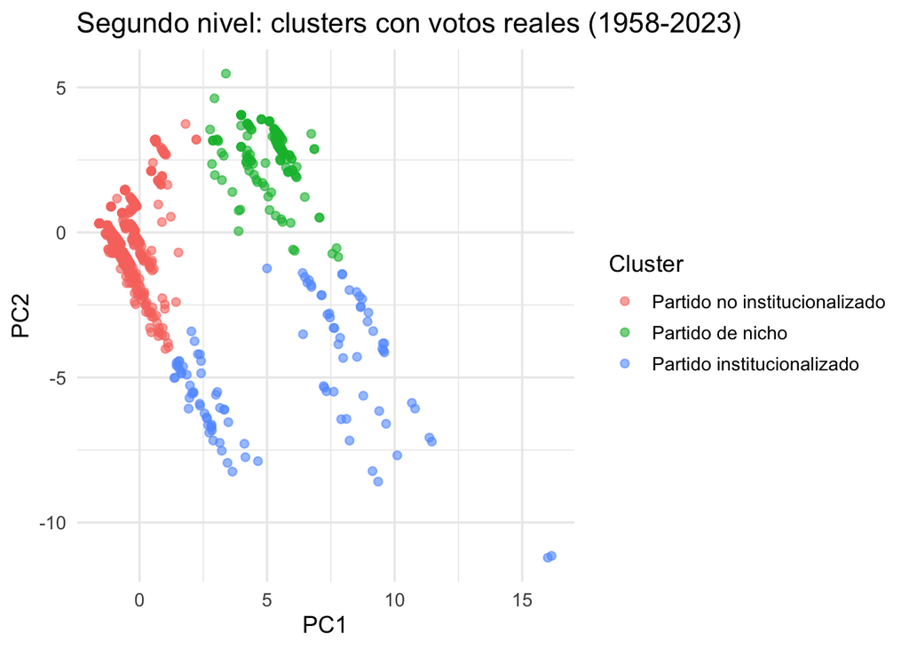

Figura 4. Segundo nivel: clusters con votos reales.

```r
pca2 <- prcomp(datos_ml2, center = TRUE, scale. = TRUE)
coord2 <- as.data.frame(pca2$x)
coord2$cluster <- base_nivel2$cluster

ggplot(coord2, aes(PC1, PC2, color = cluster)) +
  geom_point(alpha = 0.6, size = 1.8) +
  theme_minimal(base_size = 13) +
  labs(title = "Segundo nivel: clusters con votos reales (1958-2023)", color = "Cluster")
```

# 13 Evidencia temporal: ¿funcionaron las reformas? (script 12)

```r
# Replica el script 12: recarga partidos.xlsx completo (no solo
# base_nivel2), calcula el periodo sobre ESA tabla, y cruza por nombre
# con el CSV de clusters. NOTA DE REPRODUCIBILIDAD: este cruce es por
# texto del nombre, no por codigo_partido; en una corrida de verificacion
# reprodujo exactamente los periodos "2003-2011" y "2011-2023" de la
# Tabla A12, pero con una diferencia de 0.1-0.3 puntos porcentuales en
# "Antes de 1991" y "1991-2003" frente al reporte (algunas filas no
# encuentran match exacto de nombre entre las dos fuentes). No cambia
# ninguna conclusion del reporte; se documenta aqui por transparencia.
## Ojo: `partidos` ya tiene una columna `cluster` (la del nivel 1, agregada
## en la sección de caracterización). Se recarga limpio desde el archivo
## fuente -tal como hace el script 12- para que el join con el cluster
## del nivel 2 no choque de nombre con el del nivel 1.
partidos_temporal <- read_excel("data/partidos.xlsx") |>
  clean_names() |>
  mutate(
    ano_fundacion = as.numeric(str_extract(temporalidad, "^[0-9]{4}")),
    es_coalicion = str_starts(toupper(trimws(nombre)), "COALICION"),
    periodo = cut(ano_fundacion,
                   breaks = c(-Inf, 1991, 2003, 2011, Inf),
                   labels = c("Antes de 1991", "1991-2003 (Const. 91)",
                              "2003-2011 (AL 01/2003)", "2011-2023 (Ley 1475/2011)"),
                   right = FALSE)
  )

nivel2_csv <- read_csv("resultados/nivel2_partidos_clusterizados.csv", show_col_types = FALSE) |>
  select(nombre, cluster) |>
  distinct(nombre, .keep_all = TRUE)

partidos_nc <- partidos_temporal |>
  filter(!es_coalicion) |>
  left_join(nivel2_csv, by = "nombre")

partidos_nc |>
  filter(!is.na(periodo), !is.na(cluster)) |>
  count(periodo, cluster) |>
  group_by(periodo) |>
  mutate(pct = round(100 * n / sum(n), 1)) |>
  select(periodo, cluster, pct) |>
  pivot_wider(names_from = cluster, values_from = pct, values_fill = 0)
```

```
## # A tibble: 4 × 4
## # Groups:   periodo [4]
##   periodo       `Partido de nicho` Partido instituciona…¹ Partido no instituci…²
##   <fct>                      <dbl>                  <dbl>                  <dbl>
## 1 Antes de 1991                2.1                    9.7                   88.2
## 2 1991-2003 (C…                5                     14                     81
## 3 2003-2011 (A…                7.1                    2.8                   90.1
## 4 2011-2023 (L…               13.1                    1.3                   85.6
## # ℹ abbreviated names: ¹`Partido institucionalizado`,
## #   ²`Partido no institucionalizado`
```

```r
# Tabla A12 del reporte
```

# 14 Longevidad organizativa: prueba independiente (script 13)

```r
# Misma logica que el script 13: primeros y ultimos 4 digitos de
# temporalidad (str_extract anclado al inicio y al final), no un
# rango sobre todas las coincidencias numericas de la cadena
base_nivel2[, `:=`(
  ano_ini = as.numeric(str_extract(temporalidad, "^[0-9]{4}")),
  ano_fin = as.numeric(str_extract(temporalidad, "[0-9]{4}$"))
)]
base_nivel2[, longevidad := ano_fin - ano_ini]

base_nivel2[!is.na(cluster), .(
  n = .N,
  longevidad_promedio = round(mean(longevidad, na.rm = TRUE), 1),
  longevidad_mediana = as.numeric(median(longevidad, na.rm = TRUE)),
  longevidad_maxima = max(longevidad, na.rm = TRUE)
), by = cluster]
```

```
##                          cluster     n longevidad_promedio longevidad_mediana
##                           <fctr> <int>               <num>              <num>
## 1:              Partido de nicho   198                 0.8                  0
## 2: Partido no institucionalizado  1854                 0.5                  0
## 3:    Partido institucionalizado   103                13.3                  8
##    longevidad_maxima
##                <num>
## 1:                25
## 2:                43
## 3:               174
```

```r
# Tabla A11 del reporte
```

# 15 Resumen de resultados clave

[output not shown]

Estos números —y las tablas y figuras completas de cada sección— son los que se citan textualmente en `reporte/Reporte_Final_Partidos_Politicos.docx`. Para el detalle metodológico de cada paso, ver los scripts individuales en `scripts/` y `scripts/REPLICACION.md`.